# Analysis of the Heart Data

Aliyu Sambo, Kamau Maina, Julian Hatwell and Paul Carter

### Introduction

- Why we chose the heart data
- Exploratory Data Analysis (EDA)
- Pre-processing
- Descriptive / Predictive Analyses

### EDA Data Summary

There are 303 rows and 14 columns (excluding column X).

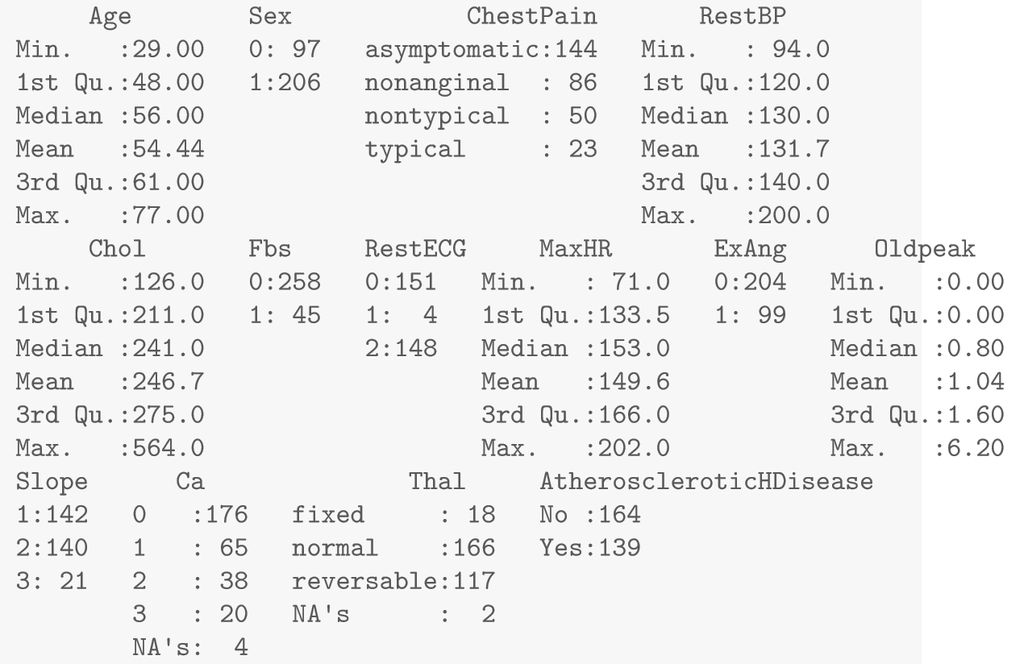

### EDA Categorical Variables

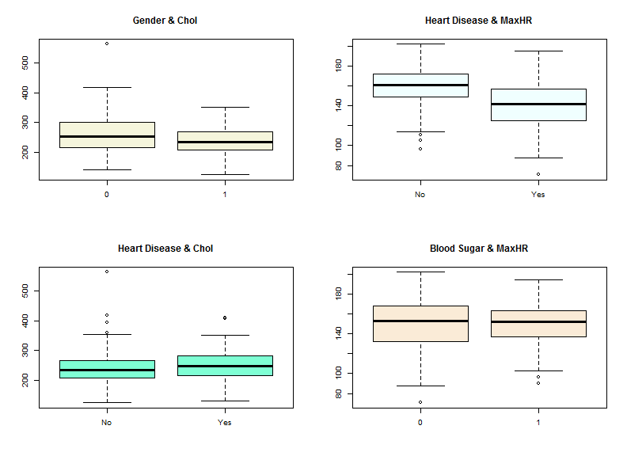

### EDA Distribution of numeric vars

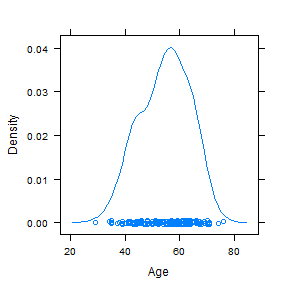

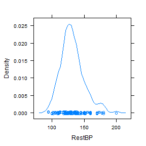

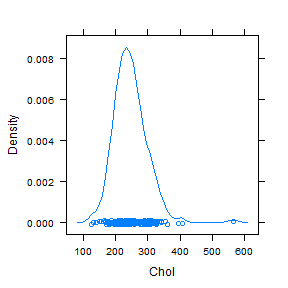

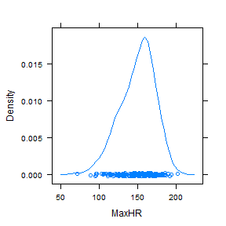

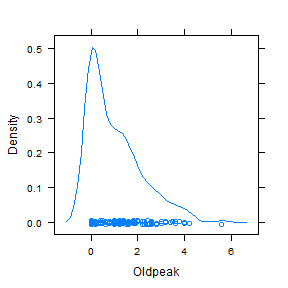

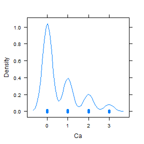

### EDA Multivariate Distribution

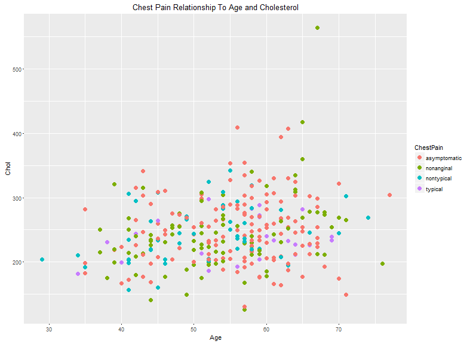

### Preprocessing

1. Drop variable X and rename AtheroscleroticHDisease
2. Recoding factors
3. Partition the data into training and test
4. Handling NA values in Thal variable
5. Handling NA values in Ca variable
6. Handling outlier in Chol variable
7. Handling skew in Oldpeak variable
8. Scaling numeric variables

### NA Values

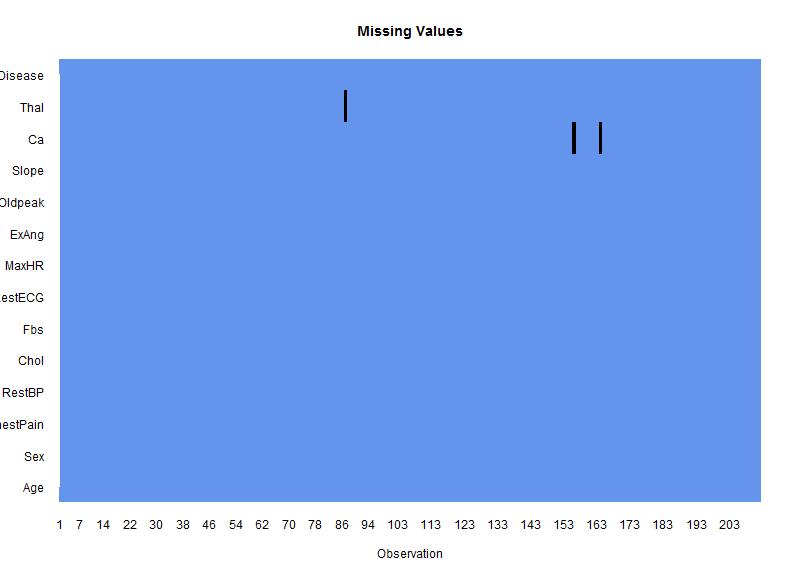

### Handling NA values in Thal variable

```r
library(Hmisc) # impute with mean/mode etc.
heart.train$Thal <- impute(heart.train$Thal, mode) # mode is "normal"
```

### Handling NA values in Ca variable

```r
sum(is.na(heart.train$Ca)) # before
```

```
[1] 2
```

### Handling NA values in Ca variable

```r
library(VIM)
heart.imputn <- heart.train[!is.na(heart.train$Ca),]
imputn.rows <- nrow(heart.imputn)
heart.NA <- heart.train[is.na(heart.train$Ca),]
heart.imp.NA <- rbind(heart.imputn, heart.NA)

hearttemp <-kNN(heart.imp.NA, "Ca")[,-15]

toputback <- hearttemp[-c(1:imputn.rows), ]
heart.train <- heart.train[!is.na(heart.train$Ca),]
heart.train <- rbind(heart.train, toputback)
```

### Handling NA values in Ca variable

```r
sum(is.na(heart.train$Ca)) # after
```

```
[1] 0
```

### Handling outlier in Chol variable

The Chol data has an outlier that is far removed from the next closest data point. This may have been an input error. It was therefore excluded from the analysis.

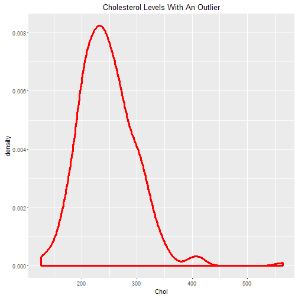

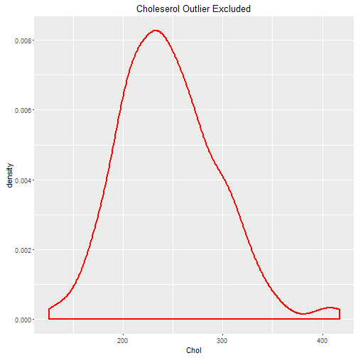

### Handling skew in Oldpeak variable

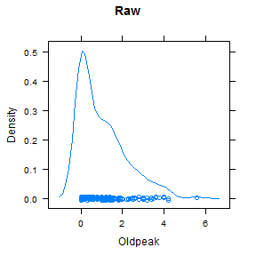

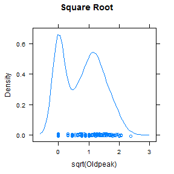

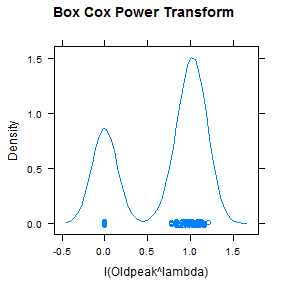

We chose square root as it is good enough and easier to explain to non-statisticians.

### Predictive and Descriptive Analyses

Each team member will now present a summary of their individual investigation

### Using Clustering to Investigate the link between Heart Disease and Chest Pain

Julian Hatwell

### Heart Disease and Chest Pain

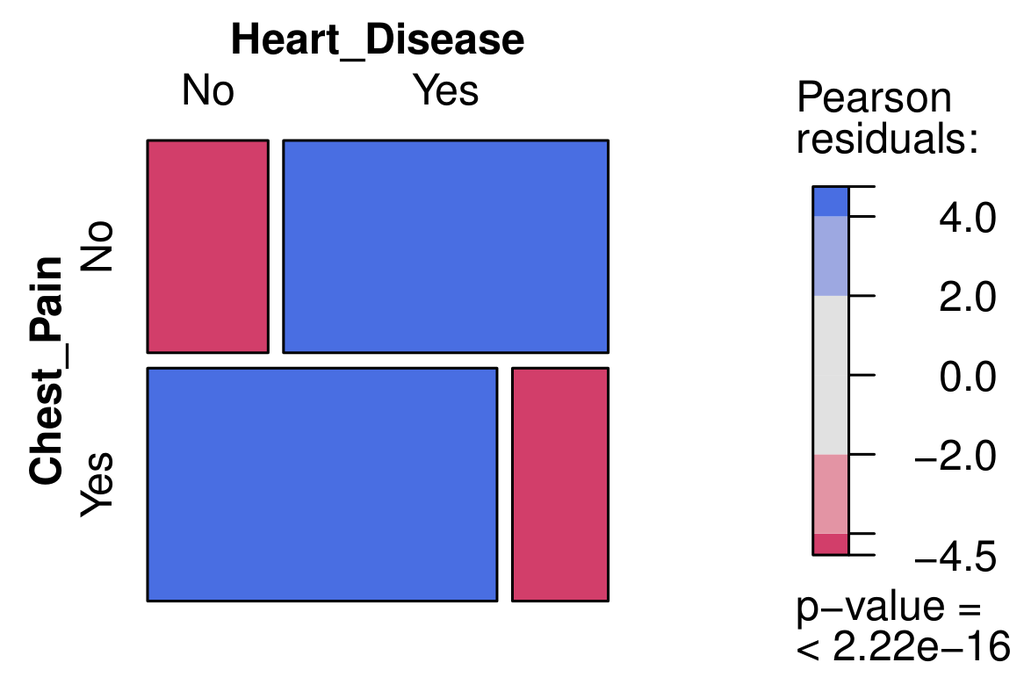

### Heart Disease and Chest Pain

- Question: Is there an underlying set of metabolic indicators associated with the pattern seen in the symptoms?
- Methodology: Remove the two variables describing the symptoms and use clustering to look for a pattern in the remaining variables.
- \( k \in \{2, 4\} \) or dendrogram cut at 2 or 4 nodes makes sense intuitively.

### Heart Disease and Chest Pain

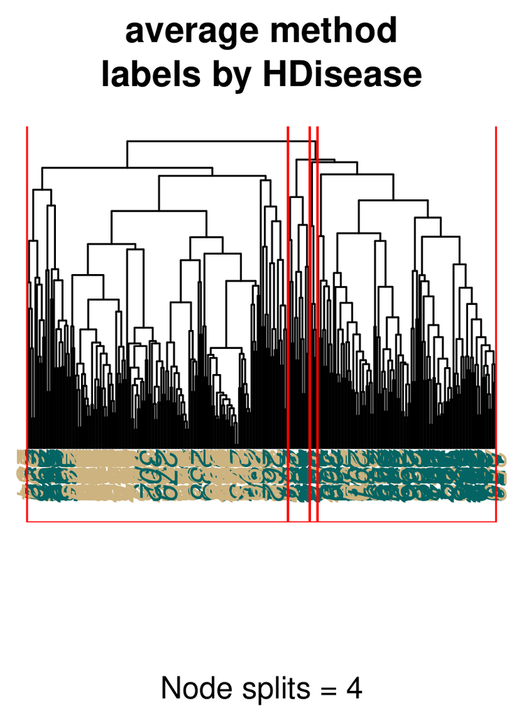

### Heart Disease and Chest Pain

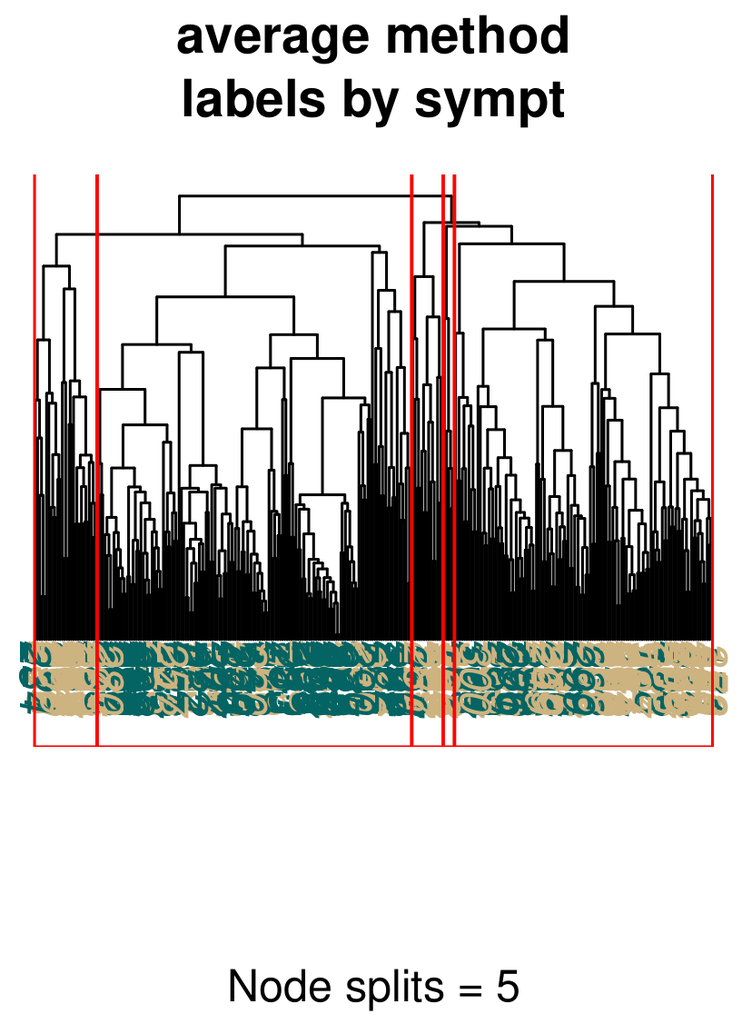

### Heart Disease and Chest Pain

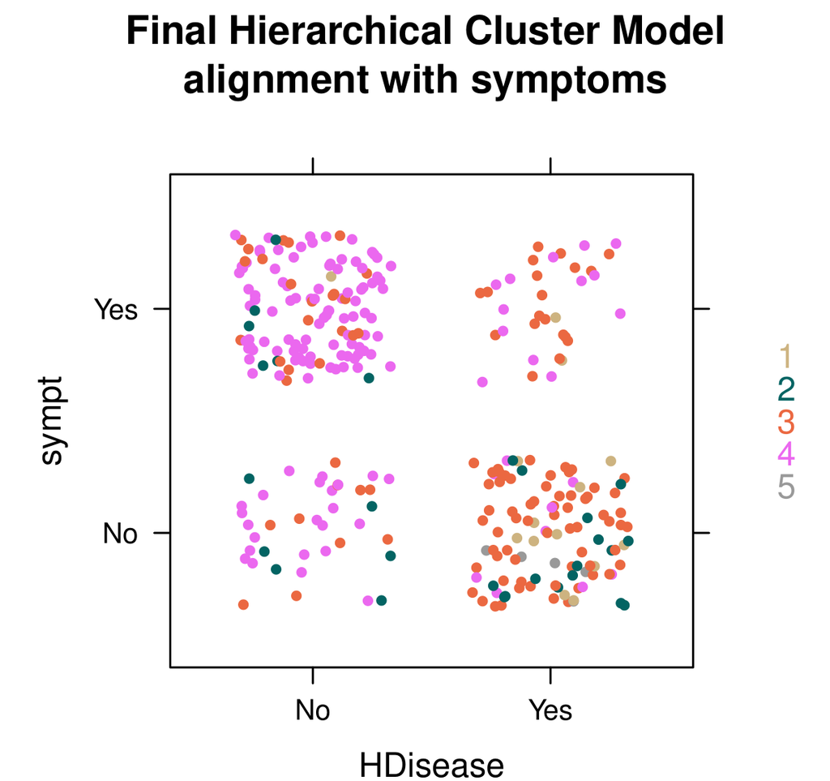

### Heart Disease and Chest Pain

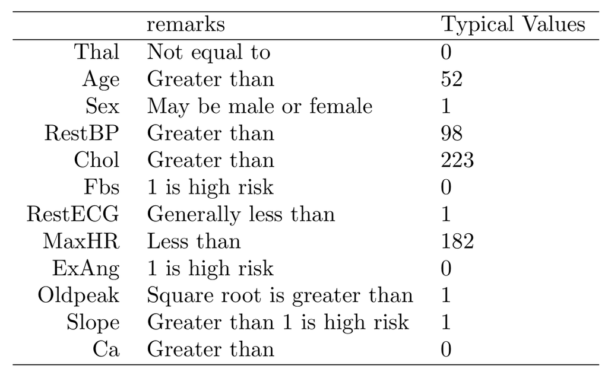

### Using Clustering to Investigate the link between Blood Sugar and Cholesterol

Kamau Maina

### Initial Visualisation

To understand the Fasting Blood Sugar date.  
False: Fastin Blood Sugar level below 120 mg/dl  
True: Fasting Blood Sugar level above 120 mg/dl

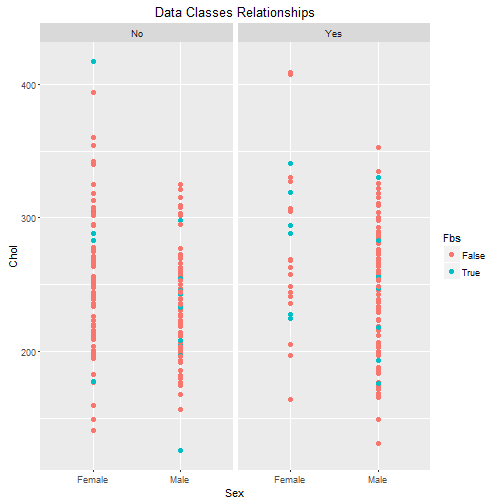

### K-Means Clustering

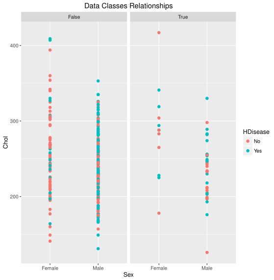

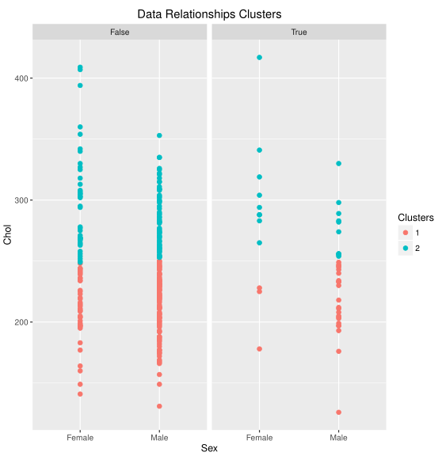

K-Means clustering clusters the data into different groups as the actual groups. This suggests that there is more that causes heart disease besides the variables at our disposal.

### Hierarchical Clustering

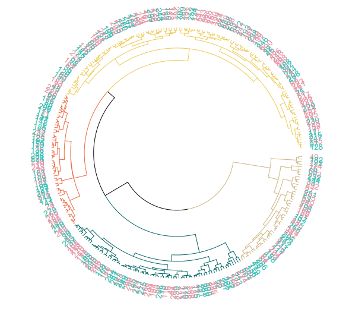

4 selected clusters are colored. Datum are colored by heart disease.

### Variable Density Heatmap

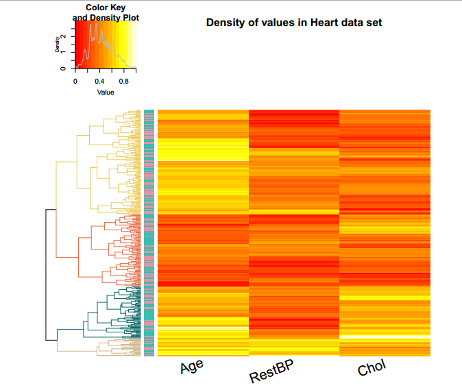

A heatmap of the density of each unique datum per variable

### Prediction of Blood Sugar Levels - a class imbalance problem

Aliyu Sambo

### Initial Naive Bayes Predictive Analysis Result

Initial Naive Bayes prediction performance for Fbs (Fasting Blood Sugar) was poor.

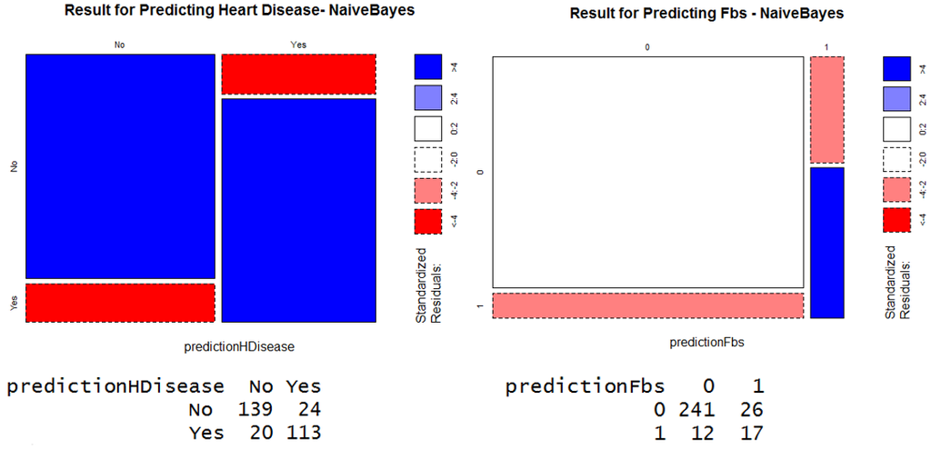

### Initial kNN Predictive Analysis Result

kNN model prediction for Fbs showed very poor performance and predict all as false.

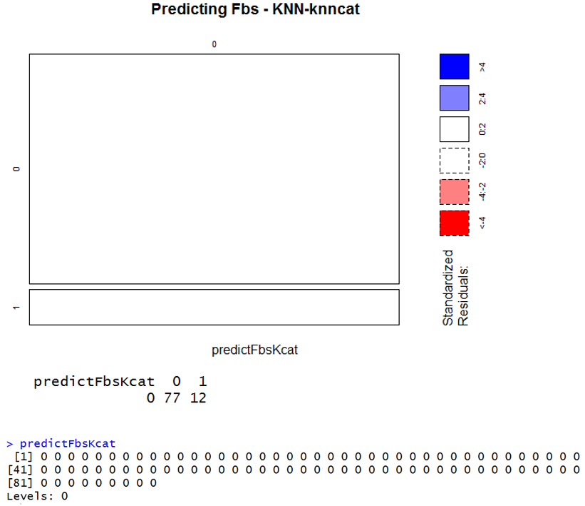

### Improvement Efforts

Feature Selection: The RELIEF and RELIEFCAT algorithms were used to identify features that features that were key.

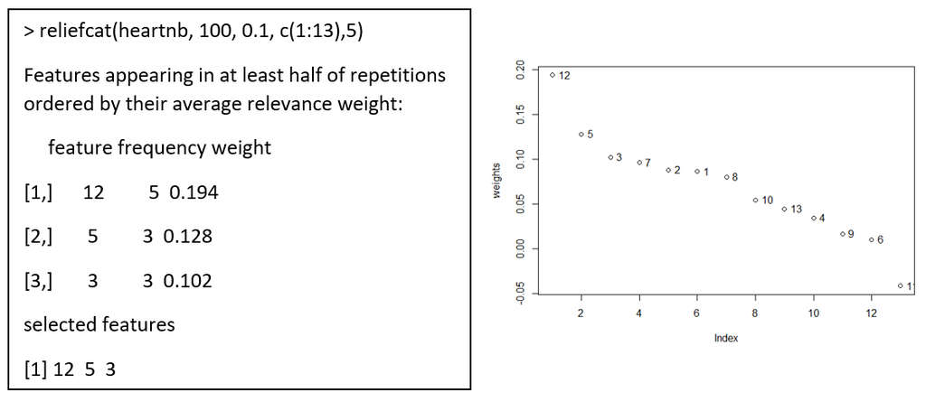

Using only key attributes did not give significant difference.

### Improvement Efforts (Contd)

- Optimising K parameter

```r
round(sqrt(nrow(heart.train)))
```

```
[1] 15
```

Therefore tried k= c(7, 9, 11, 13, 15, 17, 19). k=13 was used.

- Rescaling of Numeric Attribute
- Binning of Numeric Attributes and apply knncat (knn categorical)

### Identified Main Cause of Poor Performance

'Class Imbalance' of Fbs identified. Ideal for predictive models is close to 50% by 50%.

```r
table(heart$Fbs)
```

```
  0   1
258  45
```

```r
table(heart$HDisease)
```

```
 No Yes
164 139
```

### Solution

There are two class imbalance mitigation approaches:

- Cost function based approaches
- Sampling based approaches: Oversampling/Undersampling/Hybrid

Oversampling (adding more of the minority class) was implemented using a function in ROSE package.

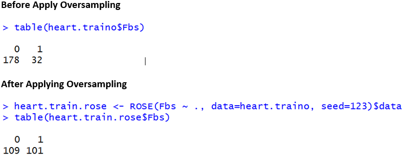

### Result After Mitigating for Class Imbalance

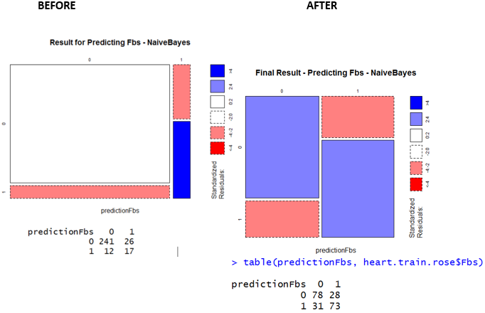

### Increasing classifier performance using data categorisation

Paul Carter

### NaiveBayes with "Raw" Heart Dataset

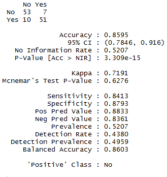

### Categorising Variables

Now let's see if the performance is better with other categorised columns

- Age from 41 values => 7 (<40, {41-46}, {47-52}, {53-58}, {59-64}, {65-70}, 71+)
- RestBP from 50 Values => 4 (Low, Ideal, Pre-High & High)
- Chol from 152 Values => 3 (Desirable, Borderline-High, High)
- MaxHR from 91 Values => 2 (Average, High)

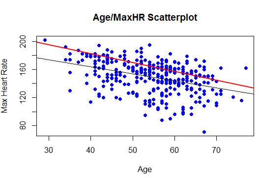